# Phenoarch platform - Cleaning procedure - Curve level - CARBayesST library

I.Sanchez

septembre 03, 2020

# 1 Objective

Detection of outliers in time courses of an experiment in PhenoArch greenhouse. In this vignette, we use a toy data set of the *openSilexStatR* library (anonymized real data set).

Please, have a look on the names of the columns of the input data set. The function is not generic and needs specific columns names in the input data set:

- Line: the x-coordinate in the lattice (numeric)
- Position: the y-coordinate in the lattice (numeric)
- Ref: a unique identifiant by pot, repetition and alias
- scenario: the scenario applied to the experiment
- genotypeAlias: the used genotypes in the experiment

The example is conducted on plantHeight parameter, we modelise the plantHeight taking into account the temporality (thermal time) and the spatiality (lattice structure) with a bayesian spatio-temporal ANOVA model [3].

To detect outlier points, we retrieve the standardised residuals computed by the model and a point is an outlier if abs(res) > *threshold* (here threshold==4). the user will be able to change this threshold.

We produced the output of the model as well as some graphics.

# 2 Import of data

The input dataset must contain some predefined columns, have a look to the structure of *mydata*:

```r
  library(lubridate)
  library(dplyr)
  library(openSilexStatR)

  myReport<-substr(now(),1,10)

  mydata<-plant1
  str(mydata)
```

```
## 'data.frame':    47022 obs. of  14 variables:
##  $ Ref            : Factor w/ 1680 levels "manip1_10_10_WW",..: 131 131 131 131 131 131 131 131 131 131 ...
##  $ experimentAlias: Factor w/ 1 level "manip1": 1 1 1 1 1 1 1 1 1 1 ...
##  $ Day            : Factor w/ 42 levels "2013-02-01","2013-02-02",..: 3 4 5 6 7 9 9 10 11 12 ...
##  $ potAlias       : int  1 1 1 1 1 1 1 1 1 1 ...
##  $ scenario       : Factor w/ 2 levels "WD","WW": 2 2 2 2 2 2 2 2 2 2 ...
##  $ genotypeAlias  : Factor w/ 274 levels "11430_H","A310_H",..: 165 165 165 165 165 165 165 165 165 165 ...
##  $ repetition     : int  1 1 1 1 1 1 1 1 1 1 ...
##  $ Line           : int  1 1 1 1 1 1 1 1 1 1 ...
##  $ Position       : int  1 1 1 1 1 1 1 1 1 1 ...
##  $ thermalTime    : num  1.29 2.65 3.98 5.32 6.66 ...
##  $ plantHeight    : num  140 151 213 239 271 ...
##  $ leafArea       : num  0.018 0.019 0.0208 0.0222 0.0235 ...
##  $ biovolume      : num  0.253 0.62 1.201 1.68 3.396 ...
##  $ Repsce         : Factor w/ 15 levels "1_WD","1_WW",..: 2 2 2 2 2 2 2 2 2 2 ...
```

# 3 CARBayesST library

A bayesian approach to model these data where the spatio-temporal structure is modelled via sets of autocorrelated random effets. Conditional autoregressive (CAR) priors and spatio-temporal extensions thereof are typically assigned to these random effects to capture the autocorrelation, which are special cases of a Gaussian Markov random Filed (GMRF) [3].

*ST.CARanova()* decomposes the spatio-temporal variation into 3 components:

- an overall spatial effect common to all time periods
- an overall temporal trend common to all spatial units
- a set of independent space-time interactions

we can add others factors (here the scenario (quali) …)

The spatio-temporal auto-correlation is modelled by a common set of spatial random effect and a common set of temporal random effects and both are modelled by the CAR prior (Conditional AutoRegressive).

**Description of the results’s table**:

- **Median**: posterior median estimation
- **2.5 and 97.5%**: 95% credible interval
- **Geweke.diag**: the convergence diagnostic implemented in the **coda** package. takes form of a Z-score, so the convergence is suggested by the statistic being **within** the range (-1.96; 1.96)

**Model fit criteria**

- DIC: deviance information criterion
- p.d: its corresponding estimated effective number of parameters
- WAIC: the Watanabe-Akaike information criterion
- p.w: its corresponding estimated number of effective parameters
- LMPL: the log marginal predictive likelihood

In model’s comparison, the best fitting model is the one that minimises the DIC and WAIC but maximises the LMPL.

**As the bayesian model can take a while, in this example, we initialise burnin=10 and n.sample=110 - not enough in real analysis!**

```
## [1] 22.35558
```

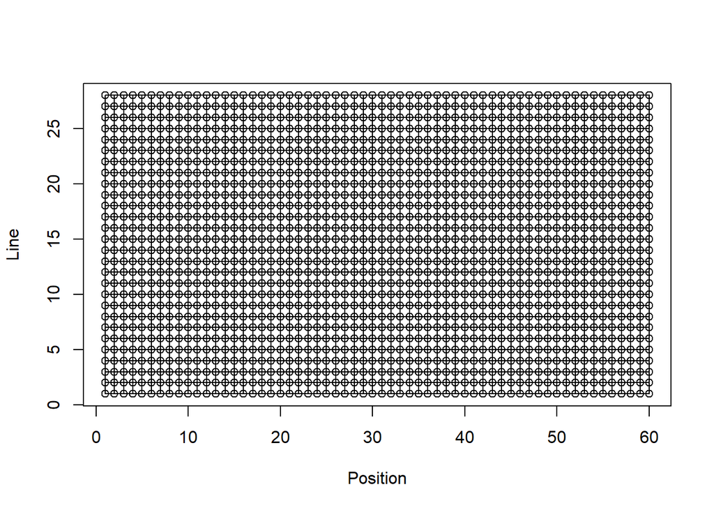

```
## Setting up the model.
## Generating 100 post burnin and thinned (if requested) samples.
##
## Summarising results.
## Finished in  134.6 seconds.
##            used  (Mb) gc trigger   (Mb) max used  (Mb)
## Ncells  3762512 201.0    6441867  344.1  3762512 201.0
## Vcells 67764920 517.1  185990965 1419.0 67764920 517.1
```

```r
  # We suppress observations with missing data in time variable (here thermalTime)
  mydata<-filter(mydata,!is.na(mydata$thermalTime))
  model<-fitCARBayesST(datain=mydata,xvar="thermalTime",trait="plantHeight",k=2,
          graphDist=TRUE,burnin=10,n.sample=110,
          formulaModel=as.formula(plantHeight~scenario+genotypeAlias),typeModel="anova",verbose=TRUE)
```

```r
  # print the result of the bayesian modelling
  printCARBayesST(modelin=model[[1]])
```

```
##                              Median       2.5%      97.5% Geweke.diag
## (Intercept)                792.4121   769.5217   826.5456        -1.4
## scenarioWW                   9.2537     1.9281    14.9508        -3.6
## genotypeAliasA310_H        -61.8629  -102.6219    -5.0264        -1.5
## genotypeAliasA347         -319.3699  -344.2097  -284.7420         0.8
## genotypeAliasA347_H        -12.9205   -45.1175    33.6987         2.1
## genotypeAliasA374_H         57.9427    -2.9565   100.8516        -0.1
## genotypeAliasA375_H         51.2212    26.3409    72.5440         0.1
## genotypeAliasA3_H           63.0665    23.5113    93.8714        -0.9
## genotypeAliasA554_H        -77.7698  -122.9195   -19.2351        -1.6
## genotypeAliasAS5707_H       14.2663   -12.1465    82.0013        -1.3
## genotypeAliasB100_H          5.7992   -23.0053    61.8494        -2.3
## genotypeAliasB104_H        -42.9152   -68.0877    14.3776        -2.4
## genotypeAliasB105_H        -59.6213  -100.8142   -25.4339         0.3
## genotypeAliasB106_H         18.9734   -16.7150    61.3870         0.3
## genotypeAliasB107_H        -43.4393   -89.0007    -7.1078        -0.3
## genotypeAliasB108_H         16.9705    -1.5067    64.0128        -0.8
## genotypeAliasB109_H          4.9318   -22.2977    42.0978        -2.1
## genotypeAliasB110_H        -53.3189   -86.7026     5.0857        -3.0
## genotypeAliasB113_H         15.1717   -19.4041    42.6992        -0.2
## genotypeAliasB14a_H        -83.2221  -115.1106   -35.0658        -0.8
## genotypeAliasB37_H         -73.6243  -112.2158   -33.0971         1.1
## genotypeAliasB73          -153.8901  -175.3168  -127.2062         2.3
## genotypeAliasB73_H           0.5651   -43.6378    61.6867         1.3
## genotypeAliasB73_SILK      -22.6728   -50.7374    20.6824        -3.1
## genotypeAliasB84_H          20.4793   -11.7302    40.7775        -2.7
## genotypeAliasB89_H         -44.6599   -81.4356    13.0737        -3.3
## genotypeAliasB97_H          62.2040    31.5570   102.2182        -2.5
## genotypeAliasB98_H         -91.4087  -151.7043   -61.5784         1.5
## genotypeAliasC103_H         -0.9394   -45.0081    32.5139         1.8
## genotypeAliasCO109_H        -2.7801   -40.9643    25.0302         0.7
## genotypeAliasCR1Ht_H       -41.4905   -77.4861    -6.5971         4.9
## genotypeAliasD09_H          24.1659    -9.1921    54.7999        -2.7
## genotypeAliasDE811_H       -88.4834  -122.8326   -44.2858        -2.1
## genotypeAliasDK2MA22_H      67.2930    30.8029   118.7684         0.3
## genotypeAliasDK4676A_H     -38.1679   -69.1596     3.0241        -0.6
## genotypeAliasDK78010_H     -84.4578  -121.5362   -42.1438        -2.8
## genotypeAliasDK78371A_H     30.3479     4.0278    90.4880        -1.0
## genotypeAliasDKFAPW_H      -29.9716   -64.9601    10.0828        -2.2
## genotypeAliasDKFBHJ_H       39.8607     6.2527    74.7926        -2.4
```

[output cut: 230 more lines]

```
## genotypeAliasW9           -477.7231  -515.5290  -449.4016         2.0
## genotypeAliasW95115_H        7.7822   -54.2033    53.7773         0.5
## genotypeAliasW9_H          -46.9783   -90.1855   -13.9738        -0.7
## genotypeAliasWf9_H         112.5164    79.0083   168.9344        -0.9
## genotypeAliasX061_H         62.1743    19.2450   106.1126        -1.4
## genotypeAliasX697_H        -11.0254   -33.9586    29.3008        -3.6
## tau2.S                    5397.7431  3875.4055  6028.8772        -3.5
## tau2.T                   45255.0079 14537.4296 88718.9426         5.3
## nu2                       6315.0429  6197.5679  9787.9819         2.5
## rho.S                        0.6217     0.5807     0.6663         1.4
## rho.T                        0.6115     0.3214     0.9115        -5.7
##           DIC           p.d          WAIC           p.w          LMPL
##    497115.191      2232.802    504471.824      6822.951   -249816.831
## loglikelihood
##   -246324.794
```

```r
  outtmp<-outlierCARBayesST(modelin=model[[1]],datain=model[[2]],threshold=4,trait="plantHeight")
```

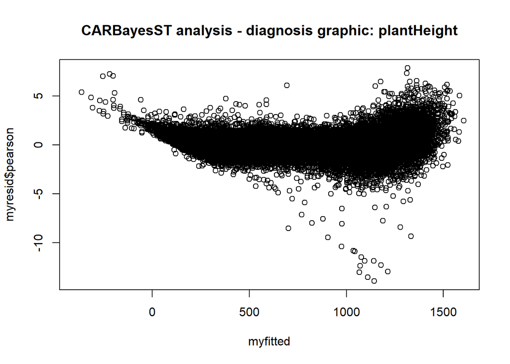

## 3.1 Outlier detection

The output report can be over-sized (more than 1Mb), for size of sub-directories in packages purposes, I choose to represent only the first genotypes…

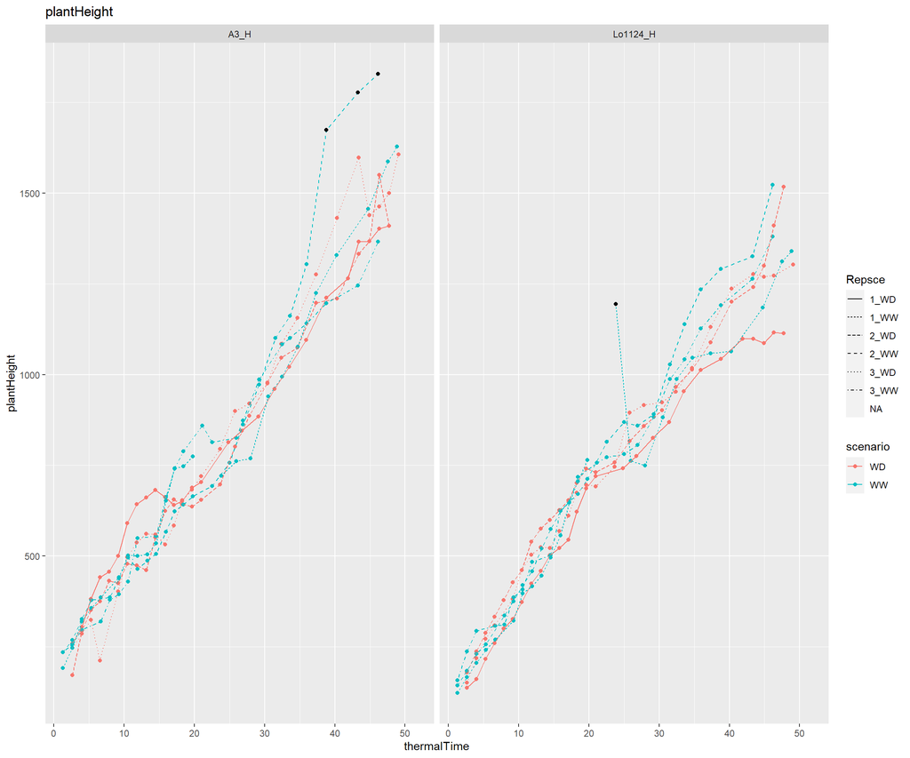

```r
  mygeno<-as.character(unique(model[[2]][,"genotypeAlias"]))
  mygeno<-mygeno[1:6]
  for (i in seq(1,length(mygeno),by=15)){
      myvec<-seq(i,i+14,1)
      plotCARBayesST(datain=model[[2]],outlierin=outtmp,myselect=myvec,trait="plantHeight",xvar="thermalTime")
  }
```

# 5 References

1. R Development Core Team (2015). R: A language and environment for statistical computing. R Foundation for Statistical Computing, Vienna, Austria. ISBN 3-900051-07-0, URL http://www.R-project.org.
2. Roger S. Bivand, Edzer Pebesma, Virgilio Gomez-Rubio, 2013. Applied spatial data analysis with R, Second edition. Springer, NY. http://www.asdar-book.org/
3. Duncan Lee, Alastair Rushworth and Gary Napier (2017). CARBayesST: Spatio-Temporal Generalised Linear Mixed Models for Areal Unit Data. R package version 2.5. https://CRAN.R-project.org/package=CARBayesST